# 43-xgboost-modeling

In this notebook, we use xgboost to perform modeling. Our general approach will be to use hyperparameter tuning via cross-validation to identify the best performing hyperparameters, In another notebook, we will investigate the performance of the model.

### 0.0.1 Useful packages

```r
xgb_recipe <-
  recipe(formula = particle_class ~ ., data = train_data) %>%
  update_role(id, img_id, starts_with('filter'), hash, new_role='no_model') %>%
  step_zv(all_predictors()) %>%
  step_normalize(all_predictors(), -all_nominal())
xgb_spec <-
  boosted_tree_mod <-boost_tree(mode = "classification", mtry = tune(), min_n = tune()) %>%
  set_engine("xgboost")
xgb_workflow <-
  workflow() %>%
  add_recipe(xgb_recipe) %>%
  add_model(xgb_spec)
xgb_parameters <- parameters(xgb_spec) %>%
  update(mtry=mtry(c(1,ncol(train_data))))
xgb_grid <- grid_max_entropy(xgb_parameters, size=20)
xgb_grid
```

| mtry | min_n |
| --- | --- |
| 19 | 40 |
| 39 | 10 |
| 47 | 3 |
| 48 | 17 |
| 6 | 5 |
| 47 | 38 |
| 14 | 13 |
| 34 | 21 |
| 31 | 3 |
| 18 | 30 |

[output cut: 10 more lines]

# 1 Hyperparameter tuning (model selection) via cross-validation

## 1.1 Cross-validation metric distributions

In this section, we’re going to take a little bit of a look at the individualized performance of the models taking into each fold into account. This will satisfy our academic curiosity in terms of machine learning and also provide some insight into the behaviors of the models. We’ll look more at the aggregated measures in a moment.

We’ll first decompress the tuning metrics a bit to get them into a more friendly form for processing.

```r
#extract the cross validation metrics for the xgb by fold (i.e., unsummarized)
xgb_fold_metrics <- xgb_tune %>%
  select(id, .metrics, .notes) %>%
  unnest(.metrics)
head(xgb_fold_metrics, 10)
```

| id | mtry | min_n | .metric | .estimator | .estimate | .config | .notes |
| --- | --- | --- | --- | --- | --- | --- | --- |
| Fold1 | 19 | 40 | accuracy | binary | 0.9642168 | Preprocessor1_Model01 |  |
| Fold1 | 19 | 40 | sens | binary | 0.6314700 | Preprocessor1_Model01 |  |
| Fold1 | 19 | 40 | spec | binary | 0.9899232 | Preprocessor1_Model01 |  |
| Fold1 | 19 | 40 | ppv | binary | 0.8288043 | Preprocessor1_Model01 |  |
| Fold1 | 19 | 40 | npv | binary | 0.9720433 | Preprocessor1_Model01 |  |
| Fold1 | 19 | 40 | f_meas | binary | 0.7168038 | Preprocessor1_Model01 |  |
| Fold1 | 19 | 40 | roc_auc | binary | 0.9650008 | Preprocessor1_Model01 |  |
| Fold1 | 19 | 40 | pr_auc | binary | 0.7937143 | Preprocessor1_Model01 |  |
| Fold1 | 39 | 10 | accuracy | binary | 0.9661470 | Preprocessor1_Model02 |  |
| Fold1 | 39 | 10 | sens | binary | 0.6935818 | Preprocessor1_Model02 |  |

Now, let’s visualize this generalized performance over all the models, both the fantastic ones and the horrible ones.

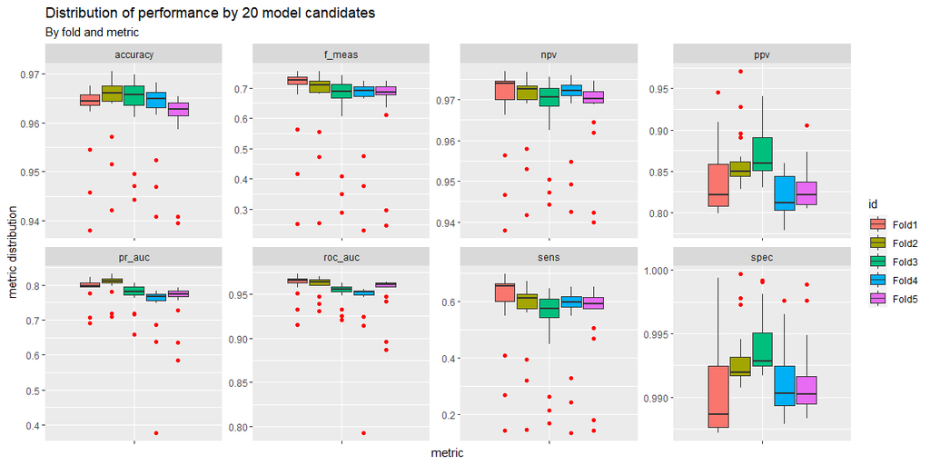

```r
xgb_fold_metrics %>%
  mutate(facet_val = if_else(.metric== 'roc_auc' | .metric=='pr_auc' | .metric=='f_meas', 'Aggregate metrics', 'Confusion matrix metrics')) %>%
  ggplot(aes(x=.metric, y=.estimate, fill=id)) +
  geom_boxplot(outlier.colour = 'red', na.rm=TRUE) +
  facet_wrap(facet='.metric', scales='free', nrow=2) +
  labs(title='Distribution of performance by 20 model candidates',
       subtitle='By fold and metric',
       x='metric',
       y='metric distribution') +
  scale_x_discrete(labels=NULL)
```